```python
import numpy as np
```

# Basic Array Creation

```python
a = np.array( (100, 101, 102, 103) )
print(a)
```

```
[100 101 102 103]
```

```python
b = np.array( [[1.,2.], [3.,4.]] )
print(b)
```

```
[[1. 2.]
 [3. 4.]]
```

```python
print(b[0,1]) # same as b[(0,1)]
b[1,1] = 0  # also for assignment
print(b)
```

```
2.0
[[1. 2.]
 [3. 0.]]
```

```python
print(np.array( [-1, 0, 2.]))  # mixture of int and float: upcast to float

print(np.array([0, 4,-4], dtype=complex))
```

```
[-1.  0.  2.]
[ 0.+0.j  4.+0.j -4.+0.j]
```

```python
print(np.empty((2,2))) # Uninitialized array with given shape.
```

```
[[1. 2.]
 [3. 0.]]
```

```python
print(np.zeros((3,2))) # default dtype is 'float '
print(np.ones((3,3), dtype=int))
```

```
[[0. 0.]
 [0. 0.]
 [0. 0.]]
[[1 1 1]
 [1 1 1]
 [1 1 1]]
```

```python
print(a)
print(np.ones_like(a))
print(np.zeros_like(a, dtype=float))
```

```
[100 101 102 103]
[1 1 1 1]
[0. 0. 0. 0.]
```

## Initializing an Array from a Sequence

```python
print(np.arange(7))
print(np.arange(1.5, 3., 0.5))
print(np.linspace(1, 20, 5))
```

```
[0 1 2 3 4 5 6]
[1.5 2.  2.5]
[ 1.    5.75 10.5  15.25 20.  ]
```

```python
x, dx = np.linspace(0., 2*np.pi, 100, retstep=True) # retstep=True returns spacing between points
print(x, "\n", dx)
```

```
[0.         0.06346652 0.12693304 0.19039955 0.25386607 0.31733259
 0.38079911 0.44426563 0.50773215 0.57119866 0.63466518 0.6981317
 0.76159822 0.82506474 0.88853126 0.95199777 1.01546429 1.07893081
 1.14239733 1.20586385 1.26933037 1.33279688 1.3962634  1.45972992
 1.52319644 1.58666296 1.65012947 1.71359599 1.77706251 1.84052903
 1.90399555 1.96746207 2.03092858 2.0943951  2.15786162 2.22132814
 2.28479466 2.34826118 2.41172769 2.47519421 2.53866073 2.60212725
 2.66559377 2.72906028 2.7925268  2.85599332 2.91945984 2.98292636
 3.04639288 3.10985939 3.17332591 3.23679243 3.30025895 3.36372547
 3.42719199 3.4906585  3.55412502 3.61759154 3.68105806 3.74452458
 3.8079911  3.87145761 3.93492413 3.99839065 4.06185717 4.12532369
 4.1887902  4.25225672 4.31572324 4.37918976 4.44265628 4.5061228
 4.56958931 4.63305583 4.69652235 4.75998887 4.82345539 4.88692191
 4.95038842 5.01385494 5.07732146 5.14078798 5.2042545  5.26772102
 5.33118753 5.39465405 5.45812057 5.52158709 5.58505361 5.64852012
 5.71198664 5.77545316 5.83891968 5.9023862  5.96585272 6.02931923
 6.09278575 6.15625227 6.21971879 6.28318531]
 0.06346651825433926
```

```python
print(np.linspace(0, 5, 5, endpoint=False))
```

```
[0. 1. 2. 3. 4.]
```

## Initializing an Array from a Function

```python
def f(i, j):
 return 2 * i * j

print(np.fromfunction(f,(4,3)))
print(np.fromfunction(lambda i,j: 2*i*j, (4,3)))
```

```
[[ 0.  0.  0.]
 [ 0.  2.  4.]
 [ 0.  4.  8.]
 [ 0.  6. 12.]]
[[ 0.  0.  0.]
 [ 0.  2.  4.]
 [ 0.  4.  8.]
 [ 0.  6. 12.]]
```

### Example E6.1

```python
N, n = 103, 3
def f(i):
  return (i % n == 0) * 1

comb = np.fromfunction(f, (N,), dtype=int) # Create array of length 103 with 1 every 3-th element
print(comb)
```

```
[1 0 0 1 0 0 1 0 0 1 0 0 1 0 0 1 0 0 1 0 0 1 0 0 1 0 0 1 0 0 1 0 0 1 0 0 1
 0 0 1 0 0 1 0 0 1 0 0 1 0 0 1 0 0 1 0 0 1 0 0 1 0 0 1 0 0 1 0 0 1 0 0 1 0
 0 1 0 0 1 0 0 1 0 0 1 0 0 1 0 0 1 0 0 1 0 0 1 0 0 1 0 0 1]
```

## ndarray Attributes for Introspection

```python
a = np.array(((1, 0, 1), (0, 1, 0)))
print(a.shape) # 2 rows, 3 columns
print(a.ndim)  # rank (number of dimensions)
print(a.size) # total number of elements
print(a.dtype)
print(a.data)
```

```
(2, 3)
2
6
int64
<memory at 0x7cd52b625080>
```

# NumPy’s Basic Data Types (dtypes)

NumPy doesn’t just store numbers the way Python does. To work fast with C code, every array element needs a fixed format in memory. That’s why NumPy uses dtypes—they tell us exactly how a number is stored, like 16-bit integers, 32-bit floats, or 128-bit complex numbers. Using the right dtype saves memory, keeps calculations accurate, and makes it possible to share data safely across different systems.

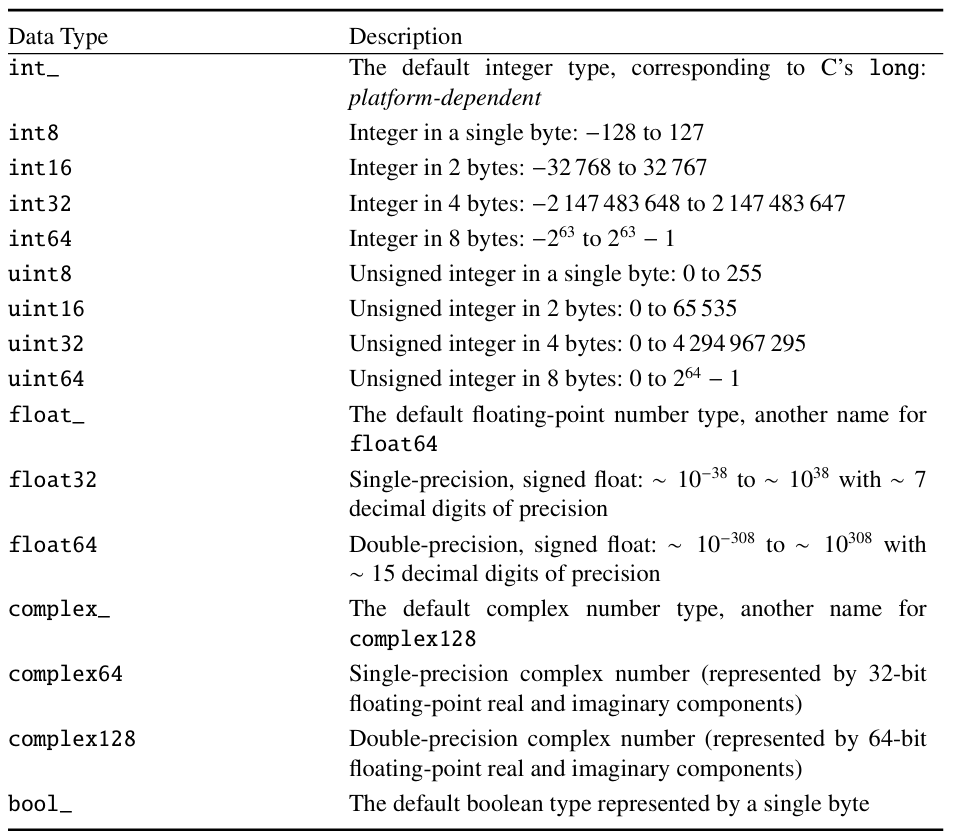

```python
import numpy as np
a = np.array([1.2, 3.4], dtype=np.float32)
b = np.array([1.2, 3.4], dtype=np.float64)
print(a.dtype, b.dtype)
print(a.nbytes, b.nbytes)  # Compare memory usage differences

c = np.array([1+2j, 3+4j])
print(c.dtype)
```

```
float32 float64
8 16
complex128
```

```python
a = np.array([1.2345678, 2.5, 3.9])
print(a.astype('uint8')) # cast to unsigned, 1-byte integer
b = np.array([1.2345678, 2.5, 3.9 ], dtype='float32')
print(a.dtype, b.dtype)
```

[output not shown]

# Universal Functions (ufuncs)

```python
# Create an array of 5 equally spaced points from 1 to 5
x = np.linspace(1, 5, 5)
print("x =", x)

# Square each element
print("x**2 =", x**2)

# Subtract 1 from each element
print("x - 1 =", x - 1)

# Square root of each element
print("sqrt(x - 1) =", np.sqrt(x - 1))

# Create another array y = exp(-t), where t ranges from 0 to 2
y = np.exp(-np.linspace(0., 2., 5))
print("y =", y)

# Apply sine to the difference (x - y)
print("sin(x - y) =", np.sin(x - y))
```

```
x = [1. 2. 3. 4. 5.]
x**2 = [ 1.  4.  9. 16. 25.]
x - 1 = [0. 1. 2. 3. 4.]
sqrt(x - 1) = [0.         1.         1.41421356 1.73205081 2.        ]
y = [1.         0.60653066 0.36787944 0.22313016 0.13533528]
sin(x - y) = [ 0.          0.98431873  0.48771645 -0.59340065 -0.98842844]
```

```python
# Define a 2x2 array
a = np.array([[1, 2],
              [3, 4]])

# Copy a into b
b = a

# Elementwise multiplication (Hadamard product)
print("Elementwise multiplication:\n", a * b)

# Matrix multiplication (dot product)
# Equivalent to: a.dot(b) or np.dot(a, b)
print("Matrix multiplication:\n", a @ b)
```

```
Elementwise multiplication:
 [[ 1  4]
 [ 9 16]]
Matrix multiplication:
 [[ 7 10]
 [15 22]]
```

```python
# Create 6 equally spaced numbers from 1 to 6, then cube each value
a = np.linspace(1, 6, 6) ** 3
print("a =", a)

# Check which elements are greater than 100
mask1 = a > 100
print("a > 100:", mask1)

# Combine conditions with logical OR: (a < 10) OR (a > 100)
mask2 = (a < 10) | (a > 100)
print("(a < 10) | (a > 100):", mask2)

# Use boolean mask to extract values
print("Values > 100:", a[mask1])
print("Values < 10 or > 100:", a[mask2])
```

```
a = [  1.   8.  27.  64. 125. 216.]
a > 100: [False False False False  True  True]
(a < 10) | (a > 100): [ True  True False False  True  True]
Values > 100: [125. 216.]
Values < 10 or > 100: [  1.   8. 125. 216.]
```

# NumPy’s Special Values, nan and inf

```python
# Create an array of [0, 1, 2, 3] with dtype float64
a = np.arange(4, dtype='f8')

# Divide each element by 0 (this will generate warnings)
a /= 0
print("a =", a)
```

```
a = [nan inf inf inf]
```

$\textbf{np.nan (Not a Number)}$ Represents the result of an undefined mathematical operation. \begin{equation} \frac{0}{0} \;\;\rightarrow\;\; \texttt{nan} \end{equation}

$\textbf{np.inf (Infinity)}$ Represents numbers that are too large or results of division by zero. \begin{equation} \frac{1}{0}, \; \frac{2}{0}, \; \frac{3}{0} \;\;\rightarrow\;\; \texttt{inf} \end{equation}

```python
# Use np.isnan, np.isinf, np.isfinite instead of equality check (nan != nan)
a = np.array([np.nan, np.inf, 2.0, 3.0])

# Check for NaN
print("isnan:", np.isnan(a))
# [ True False False False]

# Check for Inf
print("isinf:", np.isinf(a))
# [False  True False False]

# Check for finite values (not nan, not inf)
print("isfinite:", np.isfinite(a))
# [False False  True  True]
```

```
isnan: [ True False False False]
isinf: [False  True False False]
isfinite: [False False  True  True]
```

# Changing the Shape of an Array

## flatten and ravel

```python
a = np.array([[1, 2, 3],
              [4, 5, 6],
              [7, 8, 9]])

# flatten() creates an independent 1D copy of 'a'
b = a.flatten()
print("b =", b)

# Modify b
b[3] = 0
print("Modified b =", b)

# 'a' is unchanged
print("a =", a)
```

```
b = [1 2 3 4 5 6 7 8 9]
Modified b = [1 2 3 0 5 6 7 8 9]
a = [[1 2 3]
 [4 5 6]
 [7 8 9]]
```

```python
a = np.array([[1, 2, 3],
        [4, 5, 6],
        [7, 8, 9]])

# --- flatten(): returns a copy ---
b = a.flatten()
b[3] = 0
print("After modifying b (flatten):")
print("b =", b)
print("a =", a)   # a is unchanged

# --- ravel(): returns a view ---
c = a.ravel()
c[3] = 0
print("\nAfter modifying c (ravel):")
print("c =", c)
print("a =", a)   # a is changed
```

```
After modifying b (flatten):
b = [1 2 3 0 5 6 7 8 9]
a = [[1 2 3]
 [4 5 6]
 [7 8 9]]

After modifying c (ravel):
c = [1 2 3 0 5 6 7 8 9]
a = [[1 2 3]
 [0 5 6]
 [7 8 9]]
```

## resize and reshape

```python
a = np.linspace(1, 4, 4)
print("Original a:", a)

# resize changes 'a' in place (modifies the original array)
a.resize(2, 2)
print("After resize:\n", a)
```

```
Original a: [1. 2. 3. 4.]
After resize:
 [[1. 2.]
 [3. 4.]]
```

```python
a = np.linspace(1, 4, 4)
print("a =", a)

# reshape creates a view (not always a copy)
b = a.reshape(2, 2)
print("b =\n", b)

# Modify b also modifies a
b[0, 0] = -99
print("\nAfter modifying b:")
print("b =\n", b)
print("a =", a)
```

```
a = [1. 2. 3. 4.]
b =
 [[1. 2.]
 [3. 4.]]

After modifying b:
b =
 [[-99.   2.]
 [  3.   4.]]
a = [-99.   2.   3.   4.]
```

## Transposing an Array

```python
# Create a 3x2 matrix
a = np.linspace(1, 6, 6).reshape(3, 2)
print("a =\n", a)

# Transpose the matrix
print("\na.transpose() =\n", a.transpose())   # same as a.T
```

```
a =
 [[1. 2.]
 [3. 4.]
 [5. 6.]]

a.transpose() =
 [[1. 3. 5.]
 [2. 4. 6.]]
```

```python
import numpy as np

b = np.array([100, 101, 102, 103])
print("b =", b)

print("b.transpose() =", b.transpose())
```

```
b = [100 101 102 103]
b.transpose() = [100 101 102 103]
```

## Merging and Splitting Arrays

```python
import numpy as np

a = np.array([0, 0, 0, 0])
b = np.array([1, 1, 1, 1])
c = np.array([2, 2, 2, 2])

print(np.vstack((a, b, c)))   # stack vertically (each array becomes a row)
print(np.hstack((a, b, c)))   # stack horizontally (arrays concatenated into one long vector)
print(np.dstack((a, b, c)))   # stack along depth (third axis), forming a 3D array
```

```
[[0 0 0 0]
 [1 1 1 1]
 [2 2 2 2]]
[0 0 0 0 1 1 1 1 2 2 2 2]
[[[0 1 2]
  [0 1 2]
  [0 1 2]
  [0 1 2]]]
```

## Indexing and Slicing an Array

```python
import numpy as np

a = np.arange(6)
print(a)
# [0 1 2 3 4 5]

print(np.hsplit(a, 3))   # split into 3 equal parts
# [array([0, 1]), array([2, 3]), array([4, 5])]
```

```
[0 1 2 3 4 5]
[array([0, 1]), array([2, 3]), array([4, 5])]
```

```python
import numpy as np

a = np.array([0, 1, 2, 3, 4, 5])
print(a)

# split at indices 2, 3, and 5
print(np.hsplit(a, (2, 3, 5))) # this is the same as the list [a[:2], a[2:3], a[3:5], a[5:]]
```

```
[0 1 2 3 4 5]
[array([0, 1]), array([2]), array([3, 4]), array([5])]
```

Suppose you have a $3 \times 3$ array to which you wish to add a row or column. Adding a row is easy with $\texttt{np.vstack}$:

```python
# Create a 3x3 array of ones
a = np.ones((3, 3))
print("Original array:\n", a)

# Add a new row [2, 2, 2] using vstack
b = np.vstack((a, np.array((2, 2, 2))))
print("\nArray after adding a row:\n", b)
```

```
Original array:
 [[1. 1. 1.]
 [1. 1. 1.]
 [1. 1. 1.]]

Array after adding a row:
 [[1. 1. 1.]
 [1. 1. 1.]
 [1. 1. 1.]
 [2. 2. 2.]]
```

Adding a column requires a bit more work, however. You can’t use $\texttt{np.hstack}$ directly:

```python
a = np.ones((3, 3))
np.hstack( (a, np.array((2, 2, 2))) )
```

```
---------------------------------------------------------------------------
ValueError                                Traceback (most recent call last)
/tmp/ipython-input-3829852418.py in <cell line: 0>()
      1 a = np.ones((3, 3))
----> 2 np.hstack( (a, np.array((2, 2, 2))) )

/usr/local/lib/python3.12/dist-packages/numpy/_core/shape_base.py in hstack(tup, dtype, casting)
    356         return _nx.concatenate(arrs, 0, dtype=dtype, casting=casting)
    357     else:
--> 358         return _nx.concatenate(arrs, 1, dtype=dtype, casting=casting)
    359
    360

ValueError: all the input arrays must have same number of dimensions, but the array at index 0 has 2 dimension(s) and the array at index 1 has 1 dimension(s)
```

Wecan’t simply transpose our new row, either, because it’s a one-dimensional array and its transpose is the same shape as the original. So we need to $reshape$ it first:

```python
# Create a 3x3 array of ones
a = np.ones((3, 3))
print("Original array:\n", a)

# Create a new column [2, 2, 2] and reshape to (3,1)
b = np.array((2, 2, 2)).reshape(3, 1)
print("\nNew column array:\n", b)

# Add the column to a using hstack
c = np.hstack((a, b))
print("\nArray after adding a column:\n", c)
```

```
Original array:
 [[1. 1. 1.]
 [1. 1. 1.]
 [1. 1. 1.]]

New column array:
 [[2]
 [2]
 [2]]

Array after adding a column:
 [[1. 1. 1. 2.]
 [1. 1. 1. 2.]
 [1. 1. 1. 2.]]
```

```python
# Create an array with 6 values between 1 and 6
a = np.linspace(1, 6, 6)
print("a =", a)

# Slice with stride of 2: elements at index 1 and 3
print(a[1:4:2])   # [2. 4.]

# Slice with stride of -2: elements at index 3 and 1
print(a[3::-2])   # [4. 2.]
```

```
a = [1. 2. 3. 4. 5. 6.]
[2. 4.]
[4. 2.]
```

## Advanced Indexing

```python
# Create a 4x3 array with values from 1 to 12
a = np.linspace(1, 12, 12).reshape(4, 3)
print("a =\n", a)

# Access element at row 3, column 1 (0-based indexing)
print(a[3, 1])   # 11.0

# Everything in the third row
print(a[2, :])   # [7. 8. 9.]

# Everything in the second column
print(a[:, 1])   # [ 2.  5.  8. 11.]

# Middle rows, second column onwards
print(a[1:-1, 1:])
# [[5. 6.]
#  [8. 9.]]
```

```
a =
 [[ 1.  2.  3.]
 [ 4.  5.  6.]
 [ 7.  8.  9.]
 [10. 11. 12.]]
11.0
[7. 8. 9.]
[ 2.  5.  8. 11.]
[[5. 6.]
 [8. 9.]]
```

```python
# Create a 4x3 array with values from 1 to 12
a = np.linspace(1, 12, 12).reshape(4, 3)
print("Original array:\n", a)

# Set all elements in the second column (index 1) to zero
a[:, 1] = 0
print("\nModified array:\n", a)
```

```
Original array:
 [[ 1.  2.  3.]
 [ 4.  5.  6.]
 [ 7.  8.  9.]
 [10. 11. 12.]]

Modified array:
 [[ 1.  0.  3.]
 [ 4.  0.  6.]
 [ 7.  0.  9.]
 [10.  0. 12.]]
```

```python
# Create array with 6 values evenly spaced between 0 and 0.5
a = np.linspace(0., 0.5, 6)
print("a:", a)

# --- Example 1: Indexing with a list ---
ia = [1, 4, 5]  # a list of indexes
print("a[ia]:", a[ia])  # pick elements at positions 1, 4, 5

# --- Example 2: Indexing with an array ---
ia = np.array(((1, 2), (3, 4)))  # 2D array of indexes
print("a[ia]:\n", a[ia])  # form a 2D array using specified indexes
```

```
a: [0.  0.1 0.2 0.3 0.4 0.5]
a[ia]: [0.1 0.4 0.5]
a[ia]:
 [[0.1 0.2]
 [0.3 0.4]]
```

```python
import numpy as np

# Create a 4x3 array with values from 1 to 12
a = np.linspace(1, 12, 12).reshape(4, 3)
print("a:\n", a)

# ia and ja are arrays of row and column indices
ia = np.array(((1, 0), (2, 1)))
ja = np.array(((0, 1), (1, 2)))

# Fancy indexing: pick elements at (ia[k], ja[k]) positions
print("a[ia, ja]:\n", a[ia, ja])
```

```
a:
 [[ 1.  2.  3.]
 [ 4.  5.  6.]
 [ 7.  8.  9.]
 [10. 11. 12.]]
a[ia, ja]:
 [[4. 2.]
 [8. 6.]]
```

Here we build a $2 \times 2$ array (the shape of the index arrays) whose elements are $a[1,0], a[0,1]$ on the top row and $a[2,1], a[1,2]$ on the bottom row.

```python
# Create a NumPy array with integers from -2 to 2
a = np.array([-2, -1, 0, 1, 2])

# Create a boolean mask array (True means select that element, False means skip)
ia = np.array([False, True, False, True, True])

# Use boolean indexing: only elements at positions with True are selected
print(a[ia])  # Output: [-1  1  2]
```

```
[-1  1  2]
```

```python
import numpy as np

# Create a NumPy array with both negative and positive values
a = np.array([-2, -1, 0, 1, 2])
print(a)  # [-2 -1  0  1  2]

# Create a boolean mask: True for elements less than 0, False otherwise
ib = a < 0
print(ib)  # [ True  True False False False]

# Replace all negative elements with 0 using boolean indexing
a[ib] = 0
print(a)  # [0 0 0 1 2]
```

```
[-2 -1  0  1  2]
[ True  True False False False]
[0 0 0 1 2]
```

```python
# Create an array with negative and positive values
a = np.array([-2, -1, 0, 1, 2])

# Replace all negative elements with 0 (in-place)
a[a < 0] = 0

# Print the updated array
print(a)  # [0 0 0 1 2]
```

```
[0 0 0 1 2]
```

```python
# Create an array with negative and positive values
a = np.array([-2, -1, 0, 1, 2])

# Replace all negative elements with 0 (in-place)
a[a < 0] = 0

# Print the updated array
print(a)  # [0 0 0 1 2]
```

```
[0 0 0 1 2]
```

```python
# Define an array of years
years = np.array([1900, 1904, 1990, 1993, 2000, 2014, 2016, 2100])

# Check leap years:
# Rule: divisible by 400 OR (divisible by 4 AND not divisible by 100)
leap_year = (years % 400 == 0) | ((years % 4 == 0) & ~(years % 100 == 0))

# Pair each year with its leap year status
print(list(zip(years, leap_year)))
# Output: [(1900, False), (1904, True), (1990, False), (1993, False),
#          (2000, True), (2014, False), (2016, True), (2100, False)]
```

```
[(np.int64(1900), np.False_), (np.int64(1904), np.True_), (np.int64(1990), np.False_), (np.int64(1993), np.False_), (np.int64(2000), np.True_), (np.int64(2014), np.False_), (np.int64(2016), np.True_), (np.int64(2100), np.False_)]
```

## Adding an Axis

```python
# Create a 2x2 array (rank = 2)
a = np.linspace(1, 4, 4).reshape(2, 2)
print(a)
# [[1. 2.]
#  [3. 4.]]
print(a.shape)  # (2, 2)

# Insert a new axis → result becomes a 3D array (rank = 3)
b = a[:, np.newaxis, :]
print(b)
# [[[1. 2.]]
#  [[3. 4.]]]
print(b.shape)  # (2, 1, 2)
```

```
[[1. 2.]
 [3. 4.]]
(2, 2)
[[[1. 2.]]

 [[3. 4.]]]
(2, 1, 2)
```

## Meshes

```python
x = np.linspace(0, 5, 6)   # [0, 1, 2, 3, 4, 5]
y = np.linspace(0, 3, 4)   # [0, 1, 2, 3]

X, Y = np.meshgrid(x, y)
print(X)
print(Y)
```

[output not shown]

A function of two coordinates can therefore be evaluated on the grid as simply $\texttt{f(X, Y)}$.

```python
Z = X**2 + Y**2
print(Z)
```

```
[[ 0.  1.  4.  9. 16. 25.]
 [ 1.  2.  5. 10. 17. 26.]
 [ 4.  5.  8. 13. 20. 29.]
 [ 9. 10. 13. 18. 25. 34.]]
```

```python
X, Y = np.meshgrid(x, y, sparse=True)
print(X)
print(Y)
```

```
[[0. 1. 2. 3. 4. 5.]]
[[0.]
 [1.]
 [2.]
 [3.]]
```

```python
Z = X**2 + Y**2
print(Z)
```

```
[[ 0.  1.  4.  9. 16. 25.]
 [ 1.  2.  5. 10. 17. 26.]
 [ 4.  5.  8. 13. 20. 29.]
 [ 9. 10. 13. 18. 25. 34.]]
```

## Broadcasting

```python
# Create a 2x3 array
a = np.array([[1, 2, 3],
              [4, 5, 6]])

# Scalar value
b = 2

# Elementwise multiplication (broadcasting)
c = a * b

print("a:\n", a)
print("b:", b)
print("c:\n", c)

# Show dimensions
print("\nThe dimensions of a and b are compatible:")
print("a:", a.shape[0], "x", a.shape[1])
print("b:", 1)
print("c:", c.shape[0], "x", c.shape[1])
```

```
a:
 [[1 2 3]
 [4 5 6]]
b: 2
c:
 [[ 2  4  6]
 [ 8 10 12]]

The dimensions of a and b are compatible:
a: 2 x 3
b: 1
c: 2 x 3
```

```python
# Create a 2x3 array
a = np.array([[1, 2, 3],
              [4, 5, 6]])

# Create a 1D array of length 3
b = np.array([1, 2, 3])

# Elementwise multiplication with broadcasting
c = a * b

print("a:\n", a)
print("b:", b)
print("c:\n", c)

# Show dimensions
print("\nThe dimensions are:")
print("a:", a.shape[0], "x", a.shape[1])
print("b:", b.shape[0])
print("c:", c.shape[0], "x", c.shape[1])
```

```
a:
 [[1 2 3]
 [4 5 6]]
b: [1 2 3]
c:
 [[ 1  4  9]
 [ 4 10 18]]

The dimensions are:
a: 2 x 3
b: 3
c: 2 x 3
```

```python
b = np.array([1, 2])
a * b
```

```
---------------------------------------------------------------------------
ValueError                                Traceback (most recent call last)
/tmp/ipython-input-2533453335.py in <cell line: 0>()
      1 b = np.array([1, 2])
----> 2 a * b

ValueError: operands could not be broadcast together with shapes (2,3) (2,)
```

```python
f = X * Y
print(f)
print("\nThe dimensions are:")
print("X:", X.shape[0], "x", X.shape[1])
print("Y:", Y.shape[0],"x", Y.shape[1])
print("f:", f.shape[0], "x", f.shape[1])
```

```
[[ 0.  0.  0.  0.  0.  0.]
 [ 0.  1.  2.  3.  4.  5.]
 [ 0.  2.  4.  6.  8. 10.]
 [ 0.  3.  6.  9. 12. 15.]]

The dimensions are:
X: 1 x 6
Y: 4 x 1
f: 4 x 6
```

```python
# Define 1D arrays
a = np.array([1, 2, 3])       # shape (3,)
b = np.array([0, 10, 100])    # shape (3,)

# Use np.newaxis to turn a into a column vector (shape (3,1))
c = a[:, np.newaxis] * b      # broadcasting multiplication

print("a:", a)
print("b:", b)
print("a * b:", a * b)
print("c:\n", c)

# Show results
print("a[:, np.newaxis]:", a[:, np.newaxis].shape[0], "x", a[:, np.newaxis].shape[1])
print("b:", b.shape[0])
print("c:", c.shape[0], "x", c.shape[1])
```

```
a: [1 2 3]
b: [  0  10 100]
a * b: [  0  20 300]
c:
 [[  0  10 100]
 [  0  20 200]
 [  0  30 300]]
a[:, np.newaxis]: 3 x 1
b: 3
c: 3 x 3
```

# Maximum and Minimum Values

```python
# Define a 3x4 array
a = np.array([[3, 0, -1, 1],
              [2, -1, -2, 4],
              [1, 7, 0, 4]])

print(a)

# Global minimum of the array
print(a.min())   # -2

# Global maximum of the array
print(a.max())   # 7

# Minimum value in each column (axis=0 means column-wise)
print(a.min(axis=0))   # [1 -1 -2 1]

# Maximum value in each row (axis=1 means row-wise)
print(a.max(axis=1))   # [3 4 7]
```

```
[[ 3  0 -1  1]
 [ 2 -1 -2  4]
 [ 1  7  0  4]]
-2
7
[ 1 -1 -2  1]
[3 4 7]
```

Often, one wants not the maximum (or minimum) value itself but its index in the array. This is what the methods $\texttt{argmin}$ and $\texttt{argmax}$ do. By default, the index returned is into the $\textit{flattened}$ array, so the actual value can be retrieved using a view on the array created by $\texttt{ravel}$:

```python
# Create the array
a = np.array([[3, 0, -1, 1],
              [2, -1, -2, 4],
              [1, 7, 0, 4]])

print("Array a:")
print(a)

# Index of the global minimum value
print(a.argmin())   # 6 → flattened index of the minimum

# Value of the global minimum using ravel
print(a.ravel()[a.argmin()])   # -2
```

[output not shown]

```python
# Row indexes of maxima in each column
row_idx = a.argmax(axis=0)
print("Row indexes of maxima in each column:", row_idx)
print("Max values in each column:", a[row_idx, np.arange(a.shape[1])])

# Column indexes of maxima in each row
col_idx = a.argmax(axis=1)
print("Column indexes of maxima in each row:", col_idx)
print("Max values in each row:", a[np.arange(a.shape[0]), col_idx])
```

```
Row indexes of maxima in each column: [0 2 2 1]
Max values in each column: [3 7 0 4]
Column indexes of maxima in each row: [0 3 1]
Max values in each row: [3 4 7]
```

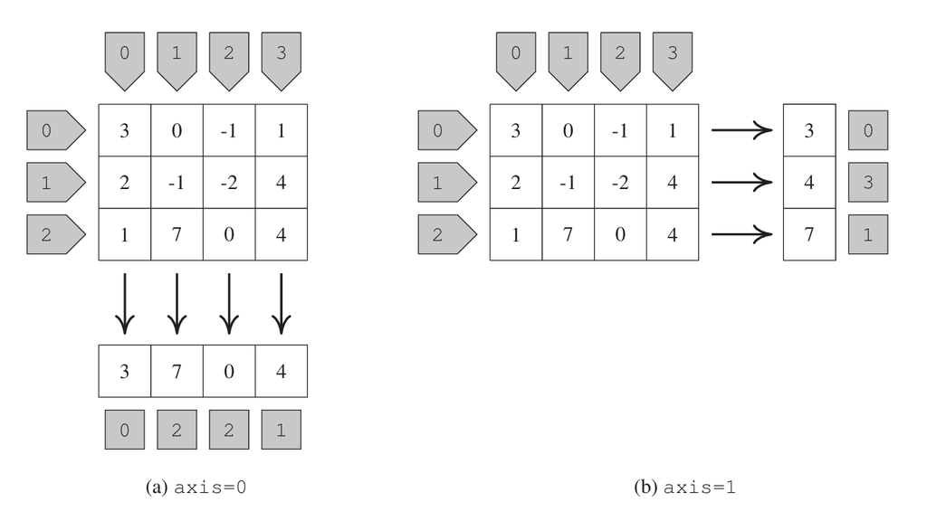

Consider the following oscillating functions on the interval $[0, L]$:

\begin{equation} f_n(x) = x(L-x) \sin \frac{2 \pi x}{\lambda_n}, \end{equation}\begin{equation} \lambda_n = \frac{2L}{n}, \quad n = 1, 2, 3, \ldots \end{equation}

The following code defines a two-dimensional array holding values of these functions for $L = 1$ on a grid of $N = 100$ points (rows) for $n = 1, 2, \ldots, 5$ (columns). The position of the maximum and minimum in each column is calculated with $\texttt{argmax(axis=0)}$ and $\texttt{argmin(axis=0)}$.

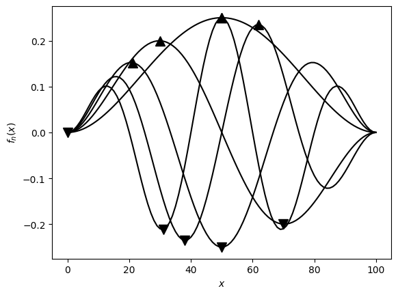

```python
# eg6-array_maxmin.py
import numpy as np
import matplotlib.pyplot as plt

# Parameters
N = 100   # number of grid points
L = 1     # interval length

# Define the function f(i, n)
def f(i, n):
    x = i * L / N
    lam = 2 * L / (n + 1)
    return x * (L - x) * np.sin(2 * np.pi * x / lam)

# Create a 2D array with shape (N+1, 5)
# Rows: x grid points, Columns: functions for n = 1,...,5
a = np.fromfunction(f, (N+1, 5))

# Find indices of minima and maxima in each column
min_i = a.argmin(axis=0)
max_i = a.argmax(axis=0)

# Plot all functions
plt.plot(a, c='k')

# Mark minima with downward triangles 'v'
plt.plot(min_i, a[min_i, np.arange(5)], 'v', c='k', markersize=10)

# Mark maxima with upward triangles '^'
plt.plot(max_i, a[max_i, np.arange(5)], '^', c='k', markersize=10)

# Labels
plt.xlabel(r'$x$')
plt.ylabel(r'$f_n(x)$')

# Show plot
plt.show()
```

# Sorting an Array

```python
# Example with 1D array
a = np.array([5, -1, 2, 4, 0, 4])
a.sort()  # sort the array in place
print(a)  # [-1  0  2  4  4  5]

# Example with 2D array
b = np.array([[0, 3, -2],
              [7, 1, 3],
              [4, 0, -1]])
print(b)

b.sort()  # sort numbers along each row
print(b)
```

```
[-1  0  2  4  4  5]
[[ 0  3 -2]
 [ 7  1  3]
 [ 4  0 -1]]
[[-2  0  3]
 [ 1  3  7]
 [-1  0  4]]
```

```python
import numpy as np

# Define a 2D array
b = np.array([[0, 3, -2],
              [7, 1, 3],
              [4, 0, -1]])

# Sort the numbers along each column (axis=0 means column-wise)
b.sort(axis=0)

# Print the result
print(b)
```

```
[[ 0  0 -2]
 [ 4  1 -1]
 [ 7  3  3]]
```

The sorting algorithm used is the “quicksort” algorithm, which is a good general purpose choice.

```python
# Define a 1D array
a = np.array([3, 0, -1, 1])

# Get the indices that would sort the array
sorted_indices = np.argsort(a)
print(sorted_indices)   # [2 1 3 0]

# Use the indices to get the sorted array
sorted_a = a[sorted_indices]
print(sorted_a)         # [-1  0  1  3]
```

```
[2 1 3 0]
[-1  0  1  3]
```

```python
import numpy as np

# Define a sorted array
a = np.array([1., 2., 3., 4.])
print("Original array:", a)

# Find the insertion index for a single value
index_single = np.searchsorted(a, 3.5)
print("Insertion index for 3.5:", index_single)  # 3

# Insert the value at the found index
a_single_insert = np.insert(a, index_single, 3.5)
print("Array after inserting 3.5:", a_single_insert)

# Find the insertion indices for multiple values
index_multiple = np.searchsorted(a, (3.5, 0, 1.1))
print("Insertion indices for (3.5, 0, 1.1):", index_multiple)  # [3 0 1]

# Insert multiple values at their respective positions
# Note: np.insert will place each value at the corresponding index
a_multiple_insert = np.insert(a, index_multiple, (3.5, 0, 1.1))
print("Array after inserting (3.5, 0, 1.1):", a_multiple_insert)
```

```
Original array: [1. 2. 3. 4.]
Insertion index for 3.5: 3
Array after inserting 3.5: [1.  2.  3.  3.5 4. ]
Insertion indices for (3.5, 0, 1.1): [3 0 1]
Array after inserting (3.5, 0, 1.1): [0.  1.  1.1 2.  3.  3.5 4. ]
```

# Structured Arrays

## Creating a Structured Array

```python
import numpy as np

# Create a structured array of length 5 with int8, float32, and complex128 fields
a = np.zeros(5, dtype=[('f0', 'int8'), ('f1', 'float32'), ('f2', 'complex128')])

# Print the array
print(a)

# Print the dtype to see field names and types
print(a.dtype)
```

```
[(0, 0., 0.+0.j) (0, 0., 0.+0.j) (0, 0., 0.+0.j) (0, 0., 0.+0.j)
 (0, 0., 0.+0.j)]
[('f0', 'i1'), ('f1', '<f4'), ('f2', '<c16')]
```

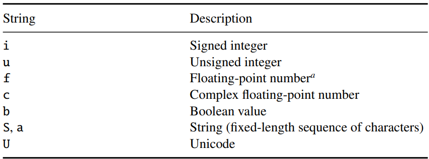

To specify the endianness, use the prefixes $\verb|>|$ (big-endian), $\verb|<|$ (little-endian) or $\verb=|=$ (endianness not relevant).

Here, we have created an array of five records, each of which has three fields, defined by constructing a \texttt{dtype} specified by the string $\texttt{'int8, float32, complex\_'}$.

- The first field is a single-byte, signed integer ($\texttt{int8}$, which is

described by the string $\texttt{'|i1'}$ -- clearly the endianness [byte order] is not relevant in a one-byte quantity).

- The second is a single-precision floating-point number, which is stored in memory (on my system) as a little-endian 4-byte sequence, indicated by $\texttt{'<f4'}$.
- The final field is defined to be a complex number to default precision, which on my system is stored in 16-bytes, little-endian ( $\texttt{complex128}$ is corresponded to a data type $\texttt{'<c16'}$).

Because we did not explicitly name the fields, they are given the default names $\texttt{'f0'}$, $\texttt{'f1'}$ and $\texttt{'f2'}$. To name the fields of our structured array explicitly, pass the $\texttt{dtype}$ constructor

```python
import numpy as np

# Define a structured data type with two fields: 'time' (float64) and 'signal' (int32)
dt = np.dtype([('time', 'f8'), ('signal', 'i4')])

# Create an array of zeros with this structured dtype
a = np.zeros(10, dtype=dt)

# Print the structured array
print(a)

# Print the dtype description
print(a.dtype)
```

```
[(0., 0) (0., 0) (0., 0) (0., 0) (0., 0) (0., 0) (0., 0) (0., 0) (0., 0)
 (0., 0)]
[('time', '<f8'), ('signal', '<i4')]
```

```python
# Assign a single record to the first element
a[0] = (0.0, 4)

# Assign multiple records to elements 1 and 2
a[1:3] = [(0.5, -3), (1.0, -5)]

# Print the structured array
print(a)
```

```
[(0. ,  4) (0.5, -3) (1. , -5) (0. ,  0) (0. ,  0) (0. ,  0) (0. ,  0)
 (0. ,  0) (0. ,  0) (0. ,  0)]
```

```python
a['time'] = np.linspace (0., 4.5, 10)

print(a)

print(a['time'][ -1])

print(a['time'])

print( a['signal'].min() )
```

```
[(0. ,  4) (0.5, -3) (1. , -5) (1.5,  0) (2. ,  0) (2.5,  0) (3. ,  0)
 (3.5,  0) (4. ,  0) (4.5,  0)]
4.5
[0.  0.5 1.  1.5 2.  2.5 3.  3.5 4.  4.5]
-5
```

## More Ways to Create a Structured Array

```python
# Define a structured dtype using a dictionary
dt = np.dtype({
    'names': ['time', 'signal'],      # field names
    'formats': ['f8', 'i4']           # corresponding data types (float64, int32)
})

# Create an array of zeros with this structured dtype
a = np.zeros(10, dtype=dt)

# Print the array
print(a)

# Print the dtype information
print(a.dtype)
```

```
[(0., 0) (0., 0) (0., 0) (0., 0) (0., 0) (0., 0) (0., 0) (0., 0) (0., 0)
 (0., 0)]
[('time', '<f8'), ('signal', '<i4')]
```

A third key, '$\texttt{titles}$', can be used to give each field a more detailed description; each title can then be used as an alias to its name in referring to that field in the array.

## Sorting Structured Arrays

```python
import numpy as np

# Define the data
data = [
    ('NiCd', 1.2, 0.14, 2000),
    ('Lead acid', 2.1, 0.14, 700),
    ('Lithium ion', 3.6, 0.46, 800)
]

# Define the dtype (structured array fields)
dtype = [
    ('name', '|S20'),               # battery name (string, max length 20 bytes)
    ('voltage', 'f8'),              # voltage (float64)
    ('specific energy', 'f8'),      # specific energy (float64)
    ('cycle durability', 'i4')      # cycle durability (int32)
]

# Create structured array
a = np.array(data, dtype=dtype)

print("Original array:")
print(a)

# Sort by "specific energy"
a.sort(order='specific energy')
print("\nSorted by specific energy:")
print(a)

# Sort by "specific energy" first, then by "voltage"
a.sort(order=['specific energy', 'voltage'])
print("\nSorted by specific energy, then voltage:")
print(a)
```

```
Original array:
[(b'NiCd', 1.2, 0.14, 2000) (b'Lead acid', 2.1, 0.14,  700)
 (b'Lithium ion', 3.6, 0.46,  800)]

Sorted by specific energy:
[(b'Lead acid', 2.1, 0.14,  700) (b'NiCd', 1.2, 0.14, 2000)
 (b'Lithium ion', 3.6, 0.46,  800)]

Sorted by specific energy, then voltage:
[(b'NiCd', 1.2, 0.14, 2000) (b'Lead acid', 2.1, 0.14,  700)
 (b'Lithium ion', 3.6, 0.46,  800)]
```

# Arrays as Vectors

```python
# Define a structured dtype with names, formats, and titles
dt = np.dtype({
    'names': ['candidate', 'mark', 'grade'],      # field names
    'formats': ['|S50', 'u1', '|S2'],             # string(50), unsigned int8, string(2)
    'titles': ['Candidate Name', 'Percentage Mark', 'Grade: A-F']
})

# Create an array of 10 zeros with this structured dtype
a = np.zeros(10, dtype=dt)

# Insert values into the array
a[0] = ('John Brown', 64, 'B-')
a[1] = ('Jane Smith', 78, 'A')

# Print specific fields using their titles
print(a['Candidate Name'])   # Access by title (Candidate Name)
print(a['Percentage Mark'])  # Access by title (Percentage Mark)
```

```
[b'John Brown' b'Jane Smith' b'' b'' b'' b'' b'' b'' b'' b'']
[64 78  0  0  0  0  0  0  0  0]
```

```python
# Define two 3D vectors as one-dimensional arrays
a = np.array([1, 0, -3])   # vector a
b = np.array([2, -2, 5])   # vector b

# Compute the dot product (scalar product)
dot_product = a.dot(b)   # or np.dot(a, b) or a @ b
print("Dot product:", dot_product)  # -13

# Compute the cross product (vector product)
cross_product = np.cross(a, b)
print("Cross product:", cross_product)  # [-6 -11  -2]
```

```
Dot product: -13
Cross product: [ -6 -11  -2]
```

```python
import numpy as np

# Define two 3x1 two-dimensional arrays (column vectors)
a = np.array([[1], [0], [-3]])   # shape (3,1)
b = np.array([[2], [-2], [5]])   # shape (3,1)

print("a:\n", a)
print("b:\n", b)

np.dot(a, b)   # tries matrix multiplication
```

```
a:
 [[ 1]
 [ 0]
 [-3]]
b:
 [[ 2]
 [-2]
 [ 5]]
```

```
---------------------------------------------------------------------------
ValueError                                Traceback (most recent call last)
/tmp/ipython-input-3158964147.py in <cell line: 0>()
      8 print("b:\n", b)
      9
---> 10 np.dot(a, b)   # tries matrix multiplication
     11

ValueError: shapes (3,1) and (3,1) not aligned: 1 (dim 1) != 3 (dim 0)
```

```python
print(np.dot(a.T[0], b.T[0]))
print(a.ravel() @ b.ravel()) # the same as a.ravel().dot(b.ravel())
```

```
-13
-13
```

```python
r = np.array([3, 4, 5])
c = r[:, np.newaxis]
print(c)
```

```
[[3]
 [4]
 [5]]
```

# Logic and Comparisons

```python
# Case 1: np.any -> True, np.all -> True
# All elements are nonzero, so "any" and "all" are both True
a1 = np.array([1, 2, 3])
print("Case 1:", np.any(a1), np.all(a1))
# (True, True)

# Case 2: np.any -> True, np.all -> False
# At least one element is nonzero, but not all of them
a2 = np.array([0, 5, 0])
print("Case 2:", np.any(a2), np.all(a2))
# (True, False)

# Case 3: np.any -> False, np.all -> False
# All elements are zero, so "any" is False and "all" is also False
a3 = np.array([0, 0, 0])
print("Case 3:", np.any(a3), np.all(a3))
# (False, False)

# Case 4: np.any -> False, np.all -> True
# Special case: an empty array
# By definition, any([]) = False and all([]) = True
a4 = np.array([])
print("Case 4:", np.any(a4), np.all(a4))
# (False, True)
```

```
Case 1: True True
Case 2: True False
Case 3: False False
Case 4: False True
```

```python
# Define an array with real and complex numbers
b = np.array([1, -1j, 0.5j, 0, 1-2.5j])

# Check which elements are real
print(np.isreal(b))
# [ True False False  True False]

# Check which elements are complex
print(np.iscomplex(b))
# [False  True  True False  True]
```

```
[ True False False  True False]
[False  True  True False  True]
```

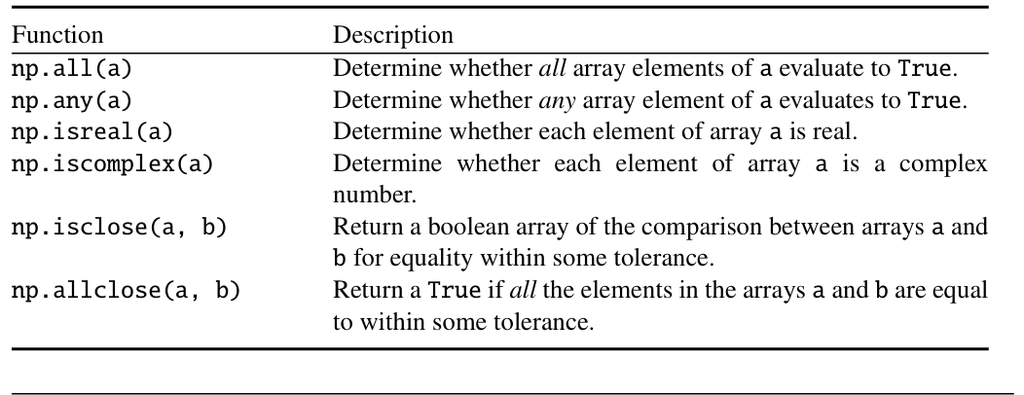

Because the representation of floating-point numbers is not exact, comparing two $\texttt{float}$ or $\texttt{complex}$ arrays with the $\texttt{==}$ operator is not always reliable and is not recommended. Instead, the best we can do is see if two values are ``close'' to one another within some (typically small) absolute or relative tolerance – NumPy provides the function $\texttt{np.isclose(a, b)}$ for elementwise comparisons of two arrays. It returns $\texttt{True}$ for elements satisfying

\begin{equation} |a - b| \leq \texttt{atol} + \texttt{rtol} \cdot |b| \end{equation}

with absolute tolerance, $\texttt{atol}$, and relative tolerance, $\texttt{rtol}$, which are $10^{-8}$ and $10^{-5}$, respectively by default but can be changed by setting the corresponding arguments.

An additional argument, $\texttt{equal_nan}$, defaults to $\texttt{False}$, meaning that $\texttt{nan}$ values in corresponding positions in the two arrays are treated as different; to treat such elements as equal, set $\texttt{equal_nan=True}$.

```python
# Define two arrays with very small/large numbers and NaN
a = np.array([1.66e-27, 1.38e-23, 6.63e-34, 6.02e23, np.nan])
b = np.array([1.66e-27, 1.66e-27, 1.66e-27, 6.00e23, np.nan])

# Compare arrays element-wise using np.isclose (without treating NaN as equal)
# Returns True if elements are "close" within tolerance
result1 = np.isclose(a, b)
print(result1)  # [ True  True  True False False]

# Compare arrays element-wise using np.isclose with equal_nan=True
# NaN values in the same position are considered equal
result2 = np.isclose(a, b, equal_nan=True)
print(result2)  # [ True  True  True False  True]
```

```
[ True  True  True False False]
[ True  True  True False  True]
```

```python
print(np.isclose(a, b, atol=0))
```

```
[ True False False False False]
```

```python
x = np.linspace(0, np.pi, 100)

# Normal allclose with default tolerance
print(np.allclose(np.sin(x)**2, 1 - np.cos(x)**2))
# True, because tiny floating-point errors are tolerated

# Strict comparison with atol=0 and rtol=0
print(np.allclose(np.sin(x)**2, 1 - np.cos(x)**2, atol=0, rtol=0))
# False, because floating-point roundoff prevents exact equality
```

```
True
False
```